# Gelada monkey parasites

Randi H. Griffin

This multifaceted project centers on the ecology of a tapeworm parasite that infects wild gelada monkeys in Ethiopia. Basic questions remain to be answered, including how the parasites impact gelada health and physiology, and how prevalent infections are. The project is lead by my labmate, Dr. India Schneider-Crease, who has done the hard work of applying for grants, collecting field data, and analyzing samples in the lab. We also draw from a decades worth of field data collected by research technicians and graduate students at the [Gelada research project](https://sites.lsa.umich.edu/gelada/) field site in Ethiopia. My job is to help clean up and make sense of this hard-earned data, and sometimes to draw cartoons of the parasite life cycle:

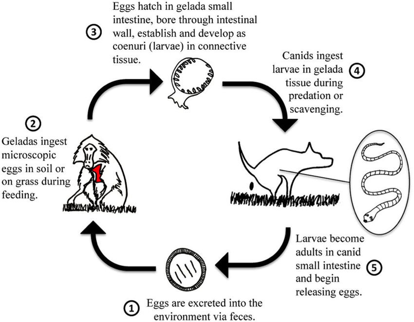

Currently, there are three parts to the project:

### Part 1: Tapeworm impact on host survival

We performed survival analyses using 10 years of longitudinal data on infection and host mortality, and found that the parasite drastically reduces host survival. Our findings were recently published in *The American Journal of Primatology* ([download](https://rgriff23.github.io/assets/pdfs/Schneider-Crease_etal_2017b.pdf)).

### Part 2: Identifying undetected tapeworms

It is possible that undetected internal cysts are causing us to underestimate prevalence based on the presence of visible external cysts, so India developed an antigen assay for detecting infections from dried urine samples. I analyzed the results with GLMMs to explore demographic patterns in infection. This study was recently published in *PLOS Neglected Tropical Diseases* ([download](https://rgriff23.github.io/assets/pdfs/Schneider-Crease_etal_2017a.pdf)).

### Part 3: Tapeworm effects on host hormones

It is hypothesized that this tapeworm species may manipulate host hormones. We use GLMMs to assess the effect of tapeworm infection on testosterone levels in males and oestrogen levels in females. We are still in the data cleaning phase of this project.